# RTP02 Exercises

### 7.1.1 Modelling using a parametric model

Decompose the time series into the components using a parametric model.

Plot the time series, including fitted values, and comment on any differences. Choose the order of the polynomial according to how good it fits the real data. Compare the orders 3, 4 and 6.

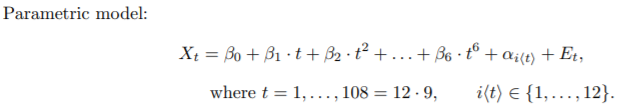

```r
Time <- 1:length(hstart.ts)
Time2 <- Time/12+1966
Months <- factor(rep(month.name, length(hstart.ts)/12), levels=month.name)
H.lm6 <- lm(hstart.ts ~ Months + Time + I(Time^2) + I(Time^3)+ I(Time^4) + I(Time^5) + I(Time^6))
H.lm3 <- lm(hstart.ts ~ Months + Time + I(Time^2) + I(Time^3))
H.lm4 <- lm(hstart.ts ~ Months + Time + I(Time^2) + I(Time^3)+I(Time^4))
H.fit6 <- ts(fitted(H.lm6), start=1966, freq=12)
H.fit3 <- ts(fitted(H.lm3), start=1966, freq=12)
H.fit4 <- ts(fitted(H.lm4), start=1966, freq=12)
```

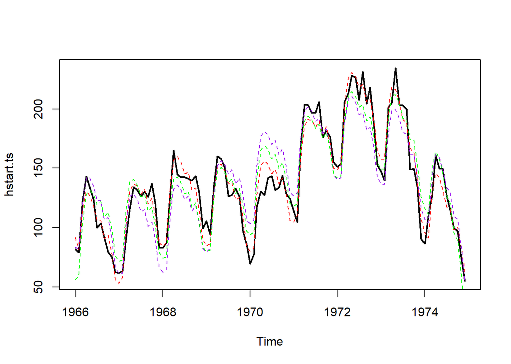

```r
plot(hstart.ts, lwd = 2)
lines(H.fit6, col = 'red', lty = 2)
lines(H.fit3, col = 'purple', lty = 2)
lines(H.fit4, col = 'green', lty = 2)
```

**c) STL decomposition** Decompose the time series in trend, seasonal component and remainder using the non-parametric STL method, and add data from this decomposition to the plot from part a).

**R hint:** The decomposition is made using **H.stl <- stl(hstart, s.window=“periodic”)**

Note: The smoothing parameter for the seasonal effect is chosen by means of s.window. - If s.window=“periodic”, the seasonal effect is estimated by averaging. - It is also possible to specify a value for the smoothing parameter (an odd number). Try e.g. H.stl.var <- stl(hstart, s.window = 15), and compare the result of this to H.stl. Incidentally, summary() can be used for displaying the values of window.

The trend estimation parameter can be set using t.window. Unlike s.window, this argument does have a default value (cf. the help file). Perhaps you could try to vary this parameter as well. The documentation for R and the help files give more details. Trend, seasonal component and remainder of the STL are stored in H.st$time.series[,"trend"] H.st$time.series[,“seasonal”] H.st$time.series[,“remainder”]

### 7.1.2 Decomposition of the time series with averaging a smoothing parameter:

```r
hstart.stl <- stl(hstart.ts, s.window = 'periodic')
summary(hstart.stl)
```

```
##  Call:
##  stl(x = hstart.ts, s.window = "periodic")
##
##  Time.series components:
##     seasonal             trend             remainder
##  Min.   :-39.33508   Min.   : 86.47829   Min.   :-19.692517
##  1st Qu.:-17.60032   1st Qu.:114.23674   1st Qu.: -5.720787
##  Median :  5.17326   Median :127.66331   Median :  0.721505
##  Mean   :  0.00000   Mean   :137.91067   Mean   :  0.083776
##  3rd Qu.: 18.23888   3rd Qu.:166.55917   3rd Qu.:  5.622462
##  Max.   : 29.58625   Max.   :198.46523   Max.   : 24.475451
##  IQR:
##      STL.seasonal STL.trend STL.remainder data
##      35.84        52.32     11.34         52.75
##    %  67.9         99.2      21.5         100.0
##
##  Weights: all == 1
##
##  Other components: List of 5
##  $ win  : Named num [1:3] 1081 19 13
##  $ deg  : Named int [1:3] 0 1 1
##  $ jump : Named num [1:3] 109 2 2
##  $ inner: int 2
##  $ outer: int 0
```

```r
str(hstart.stl)
```

```
## List of 8
##  $ time.series: Time-Series [1:108, 1:3] from 1966 to 1975: -39.34 -38.22 5.59 27.64 29.59 ...
##   ..- attr(*, "dimnames")=List of 2
##   .. ..$ : NULL
##   .. ..$ : chr [1:3] "seasonal" "trend" "remainder"
##  $ weights    : num [1:108] 1 1 1 1 1 1 1 1 1 1 ...
##  $ call       : language stl(x = hstart.ts, s.window = "periodic")
##  $ win        : Named num [1:3] 1081 19 13
##   ..- attr(*, "names")= chr [1:3] "s" "t" "l"
##  $ deg        : Named int [1:3] 0 1 1
##   ..- attr(*, "names")= chr [1:3] "s" "t" "l"
##  $ jump       : Named num [1:3] 109 2 2
##   ..- attr(*, "names")= chr [1:3] "s" "t" "l"
##  $ inner      : int 2
##  $ outer      : int 0
##  - attr(*, "class")= chr "stl"
```

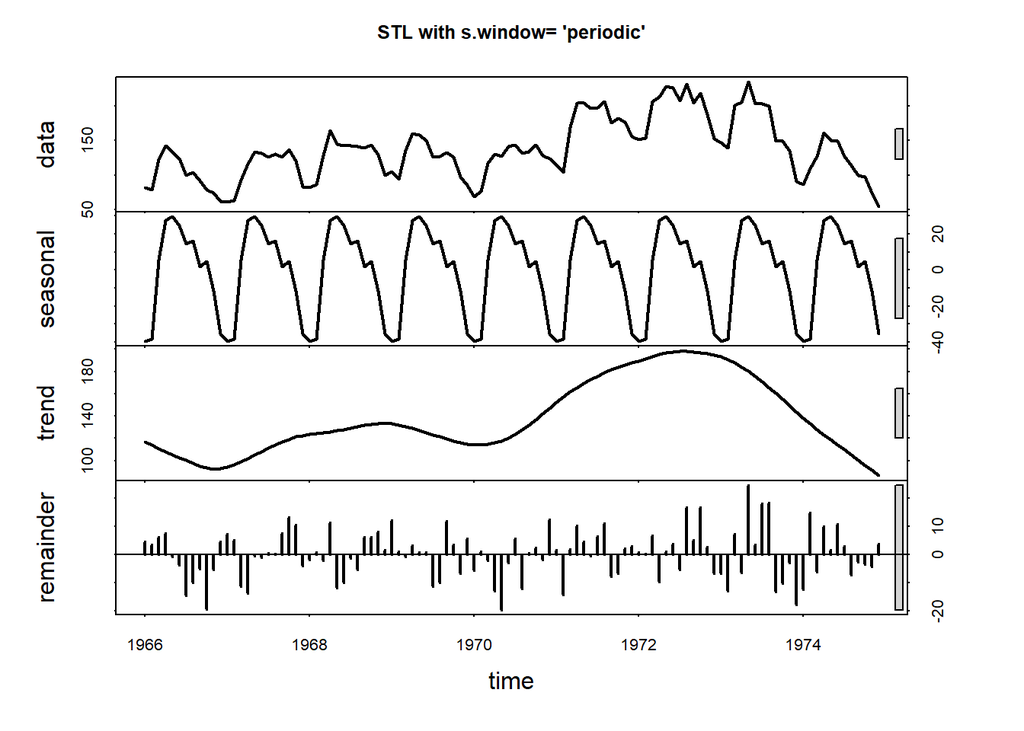

```r
plot(hstart.stl, main = "STL with s.window= 'periodic'", lwd = 2)
```

In the plot, we have the original data, additive seasonal effects, the trend curve and the residuals (remainder) of the STL decomposition, drawn in order from top to bottom.

### 7.1.3 Decomposition of the time series by manually choosing a smoothing parameter:

```r
hstart.stl.var <- stl(hstart.ts, s.window = 15)
summary(hstart.stl.var)
```

```
##  Call:
##  stl(x = hstart.ts, s.window = 15)
##
##  Time.series components:
##     seasonal             trend             remainder
##  Min.   :-40.99656   Min.   : 86.12904   Min.   :-21.661154
##  1st Qu.:-17.70703   1st Qu.:114.64695   1st Qu.: -6.058398
##  Median :  5.52532   Median :128.41074   Median :  1.289131
##  Mean   :  0.00057   Mean   :137.85127   Mean   :  0.142598
##  3rd Qu.: 19.20394   3rd Qu.:166.03389   3rd Qu.:  5.118463
##  Max.   : 30.47459   Max.   :197.60258   Max.   : 25.067960
##  IQR:
##      STL.seasonal STL.trend STL.remainder data
##      36.91        51.39     11.18         52.75
##    %  70.0         97.4      21.2         100.0
##
##  Weights: all == 1
##
##  Other components: List of 5
##  $ win  : Named num [1:3] 15 21 13
##  $ deg  : Named int [1:3] 0 1 1
##  $ jump : Named num [1:3] 2 3 2
##  $ inner: int 2
##  $ outer: int 0
```

```r
str(hstart.stl.var)
```

```
## List of 8
##  $ time.series: Time-Series [1:108, 1:3] from 1966 to 1975: -36.98 -38.01 5.33 27.52 27.46 ...
##   ..- attr(*, "dimnames")=List of 2
##   .. ..$ : NULL
##   .. ..$ : chr [1:3] "seasonal" "trend" "remainder"
##  $ weights    : num [1:108] 1 1 1 1 1 1 1 1 1 1 ...
##  $ call       : language stl(x = hstart.ts, s.window = 15)
##  $ win        : Named num [1:3] 15 21 13
##   ..- attr(*, "names")= chr [1:3] "s" "t" "l"
##  $ deg        : Named int [1:3] 0 1 1
##   ..- attr(*, "names")= chr [1:3] "s" "t" "l"
##  $ jump       : Named num [1:3] 2 3 2
##   ..- attr(*, "names")= chr [1:3] "s" "t" "l"
##  $ inner      : int 2
##  $ outer      : int 0
##  - attr(*, "class")= chr "stl"
```

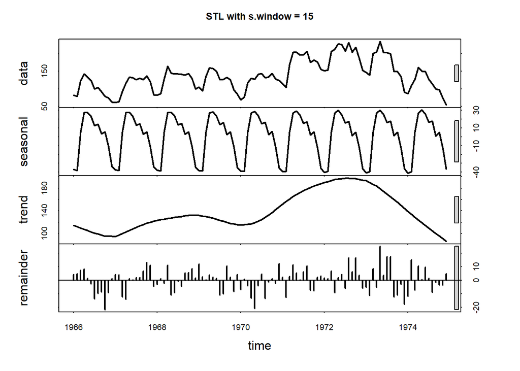

```r
plot(hstart.stl.var, main = 'STL with s.window = 15', lwd = 2)
```

### 7.1.4 Compare the averaging and manually choosen parameter for the STL:

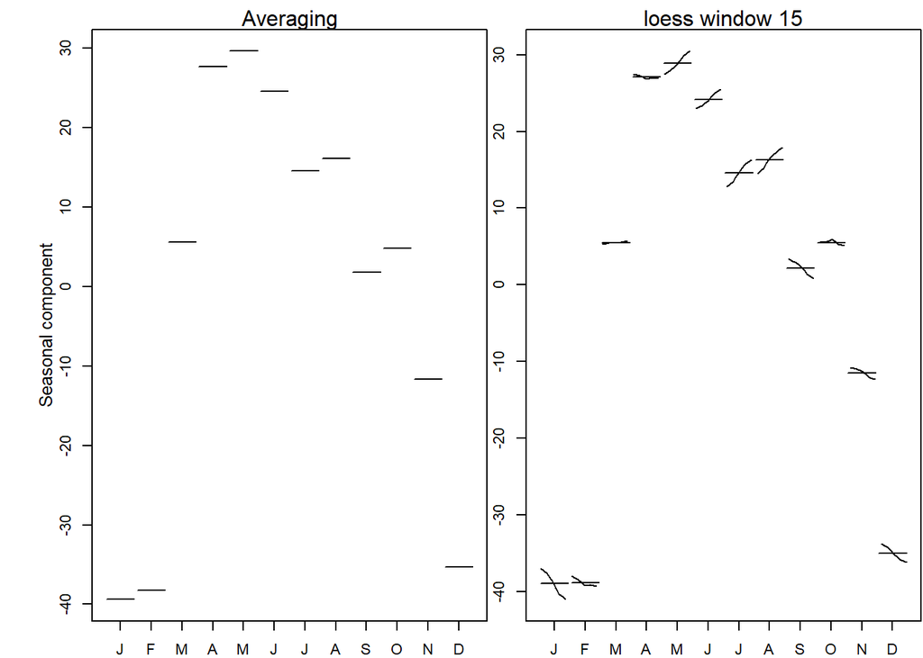

```r
par(mfrow = c(1, 2), cex = 0.7, mar = c(2, 2, 0.1, 0.1), oma = c(0, 3, 1.5, 0))
monthplot(hstart.stl$time.series[, "seasonal"], ylab = "")
mtext("Averaging", side = 3)
mtext("Seasonal component", side = 2, line = 2, cex = 0.8)
monthplot(hstart.stl.var$time.series[, "seasonal"], ylab = "")
mtext("loess window 15", side = 3)
```

Answer: We see that the monthly effects of hstart.stl remain constant over the years, whereas those of hstart.stl.var vary: the effects of May to August increase with the years, while the effects of January, September and December decrease.

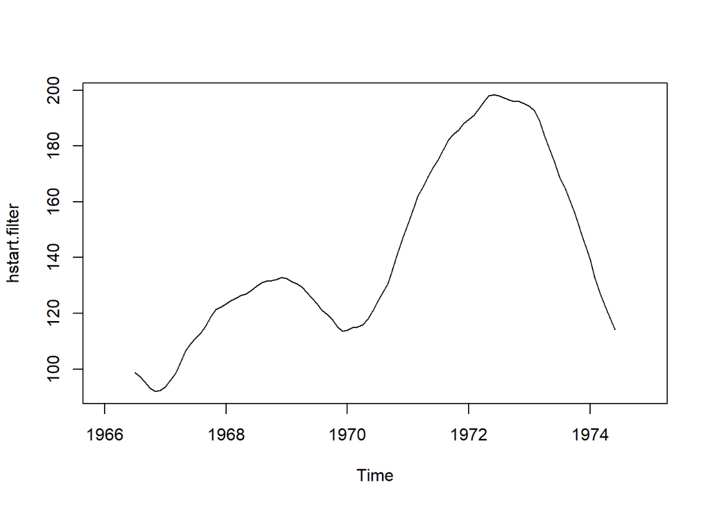

```r
hstart.filter <- filter(hstart.ts, c(1,rep(2,11), 1)/24)
plot(hstart.filter)
```

Answer: The trend line from the special filter is somewhat less smoooth then the trend line stemming from the STL decomposition. However, the smoothness of the STL trend line can be steered by the smoothness parameter **t.window** of the function stl().

### 7.1.5 Plot the original data and the STL-Decomposition (trend + season without remainder) vs. time.

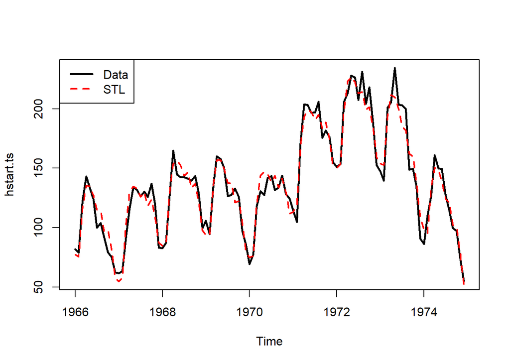

```r
plot(hstart.ts, lwd = 2.5)
lines(hstart.ts - hstart.stl$time.series[,'remainder'],lwd = 2, lty = 'dashed',main = "Data vs. STL", col = 'red')
legend('topleft', legend = c('Data', 'STL'), col = c(1,2), lty = c(1,2), lwd = c(2.5,2))
```

Answer: The non-parametric model STL fits the data better than the parametric one does.

### 7.1.6 Plot the remainder only from the STL-Decomposition vs. time.

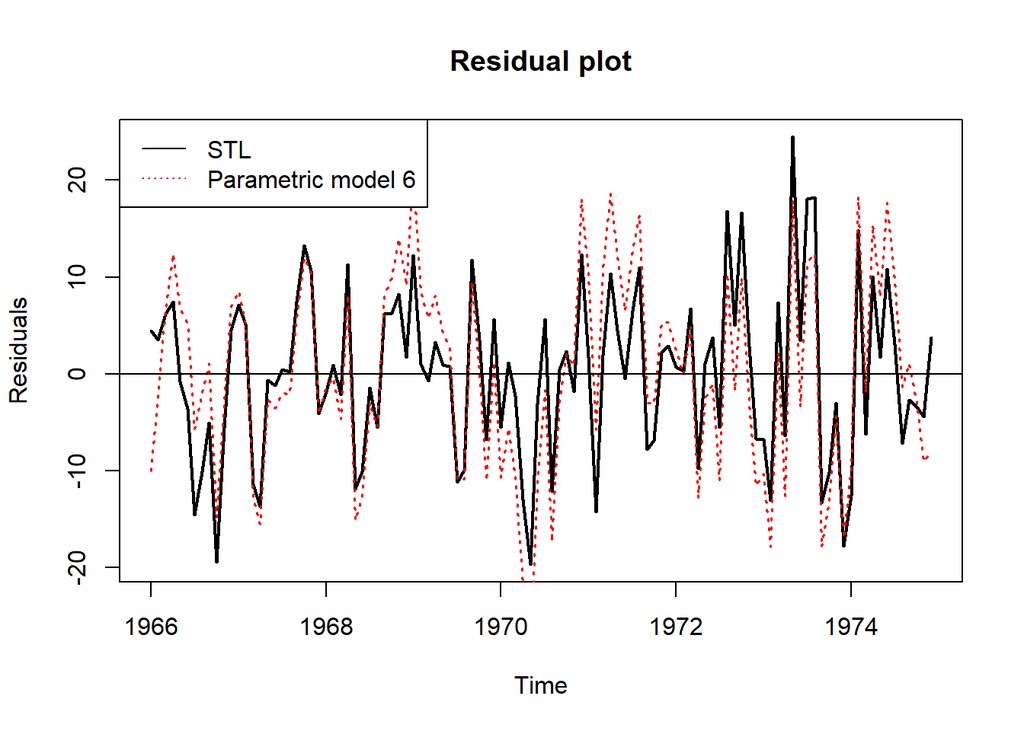

```r
plot(ts(hstart.stl$time.series[,'remainder'], start = c(1966,1), frequency = 12),lty = 1, lwd = 2, ylab='Residuals', main = 'Residual plot', col = 1)
lines(ts(resid(H.lm6), start = 1966, frequency = 12), lty=3, col =2, lwd = 1.5)
abline(h=0)
legend('topleft', legend=c("STL","Parametric model 6"), lty=c(1,3), col=c(1,2))
```

No systematic behavior is visible in the Residual plot and hence it could be concluded that the combination of the estimated trend and the seasonal effect fits the data reasonably well. the discrepancies between the two models are quite visible. Over certain intervals of time, the residuals of the parametric model differ from zero in a systematic way.

### 7.1.7 Calculating the decomposition

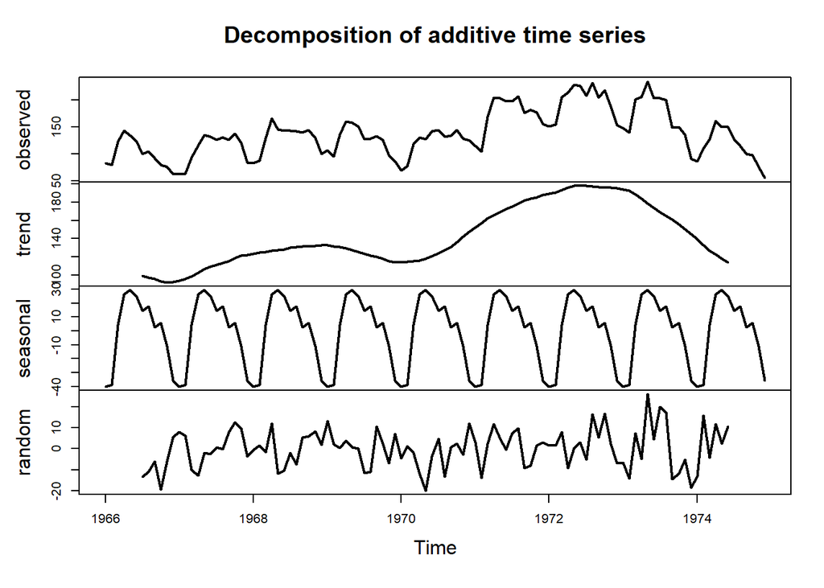

```r
hstart.decomp <- decompose(hstart.ts, type = 'additive')
plot(hstart.decomp, lwd = 2)
```

### 7.1.8 Plot the time series and three different estimates of the rend into one plot:

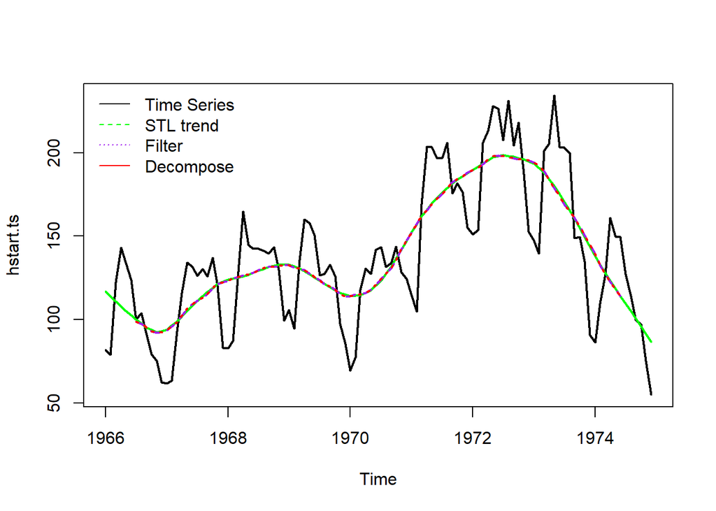

```r
plot(hstart.ts, lwd = 2)
lines(hstart.stl$time.series[,'trend'], lty =1, col = 'green', lwd = 2)
lines(hstart.filter, lty = 2, col = 'purple', lwd = 2)
lines(hstart.decomp$trend, lty = 3, col = 'red', lwd = 2)
legend('topleft', legend = c('Time Series', 'STL trend', 'Filter', 'Decompose'), lty = c(1,2,3), bty = 'n', col = c('black', 'green', 'purple', 'red'))
```

We reconsider the data set from exercise 1.2 about residential construction in the USA from January 1966 to December 1974.

```r
hstart <- read.table('https://stat.ethz.ch/Teaching/Datasets/WBL/hstart.dat')
head(hstart)
```

```
##      V1
## 1  81.9
## 2  79.0
## 3 122.4
## 4 143.0
## 5 133.9
## 6 123.5
```

```r
ts.hstart <- ts(hstart[,1], start = c(1966,1), frequency = 12)
ts.hstart
```

```
##        Jan   Feb   Mar   Apr   May   Jun   Jul   Aug   Sep   Oct   Nov   Dec
## 1966  81.9  79.0 122.4 143.0 133.9 123.5 100.0 103.7  91.9  79.1  75.1  62.3
## 1967  61.7  63.2  92.9 115.9 134.2 131.6 126.1 130.2 125.8 137.0 120.2  83.1
## 1968  82.7  87.2 128.6 164.9 144.5 142.5 142.3 141.0 139.5 143.3 129.5  99.3
## 1969 105.8  94.6 135.6 159.9 157.7 150.5 126.5 127.5 132.9 125.8  97.4  85.3
## 1970  69.2  77.2 117.8 130.6 127.3 141.9 143.5 131.5 133.8 143.8 128.3 124.1
## 1971 114.8 104.6 169.3 203.6 203.5 196.8 197.0 205.9 175.6 181.7 176.4 155.3
## 1972 150.9 153.6 205.8 213.2 227.9 226.2 207.5 231.0 204.4 218.2 187.1 152.7
## 1973 147.3 139.5 201.1 205.4 234.2 203.4 203.2 199.9 148.9 149.5 134.6  90.6
## 1974  86.2 109.6 127.2 160.9 149.9 149.5 127.2 114.0  99.6  97.2  75.1  54.9
```

**a) Decompose the time series in trend, seasonal component and remainder using the non-parametric STL method, and plot the results.**

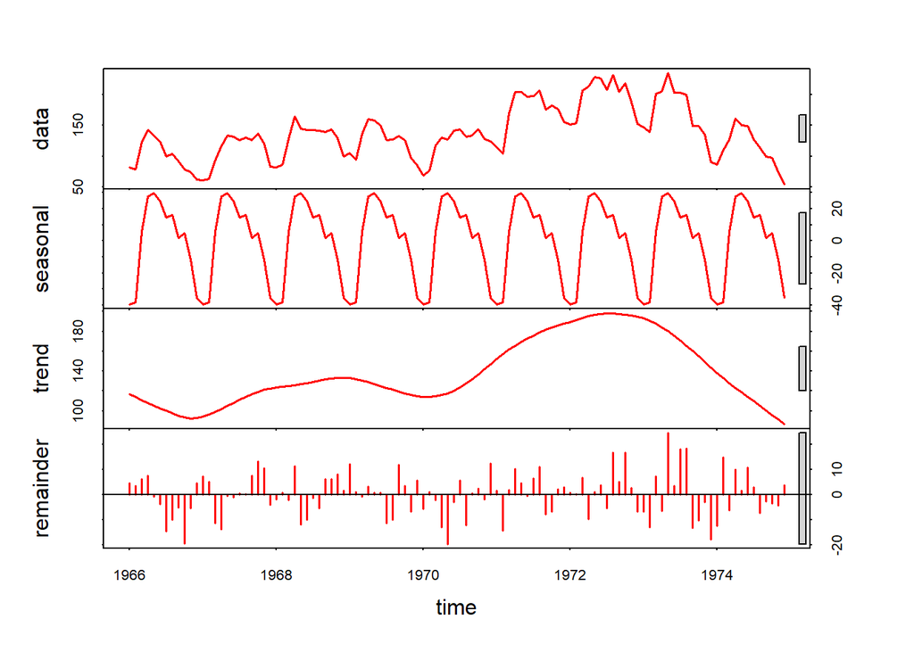

```r
hstart.stl <- stl(ts.hstart, s.window = 'per')

plot(hstart.stl, lwd = 1.5, col = 'red')
```

**b) The special filter Yt = 1/24 (Xt−6 + 2Xt−5 + … + 2Xt + … + Xt+6) can be used for computing a trend estimate.**

```r
weights <- c(1, rep(2,11), 1)/24 # total of 13 values because t-6 unti t+6
weights
```

```
##  [1] 0.04166667 0.08333333 0.08333333 0.08333333 0.08333333 0.08333333
##  [7] 0.08333333 0.08333333 0.08333333 0.08333333 0.08333333 0.08333333
## [13] 0.04166667
```

```r
hstart.filtertrend <- filter(ts.hstart, filter = weights, sides = 2)
hstart.stl <- stl(ts.hstart, s.window = 'per')
```

Plot this, the STL trend and the data in a single plot. What are the differences between the two methods?

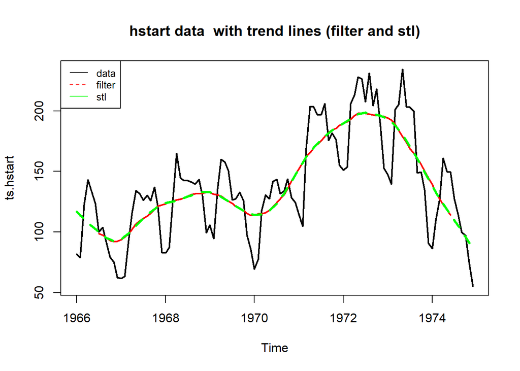

```r
plot(ts.hstart, lwd = 2, main = 'hstart data  with trend lines (filter and stl)')
lines(hstart.filtertrend, col = 'red', lwd = 2)
lines(hstart.stl$time.series[,'trend'], col = 'green', lwd = 3, lty = 2)
legend('topleft', legend = c('data', 'filter', 'stl'), lty = 1:2, col = c('black', 'red', 'green'), cex = 0.8)
```

**c) Try to remove the trend and seasonal effects by computing differences. After removing seasonal effects, choose some linear trend elimination method and plot the outcome.**

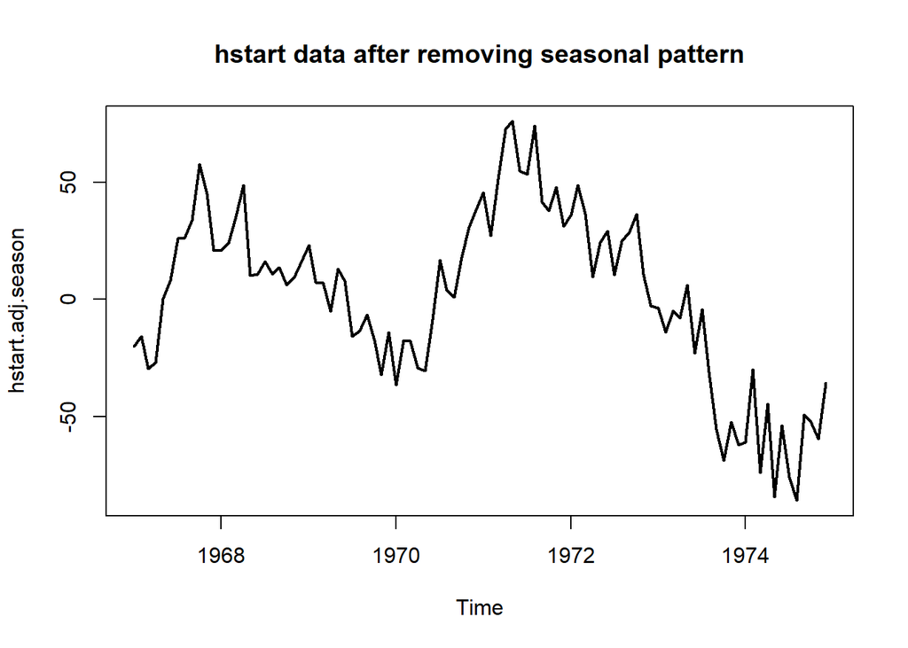

```r
hstart.adj.season <- diff(ts.hstart, lag = 12, differences = 1)
plot(hstart.adj.season, lwd = 2, main = 'hstart data after removing seasonal pattern')
```

A trend is still visible, eliminate it with backward differencing once more to produce a stationary time series.

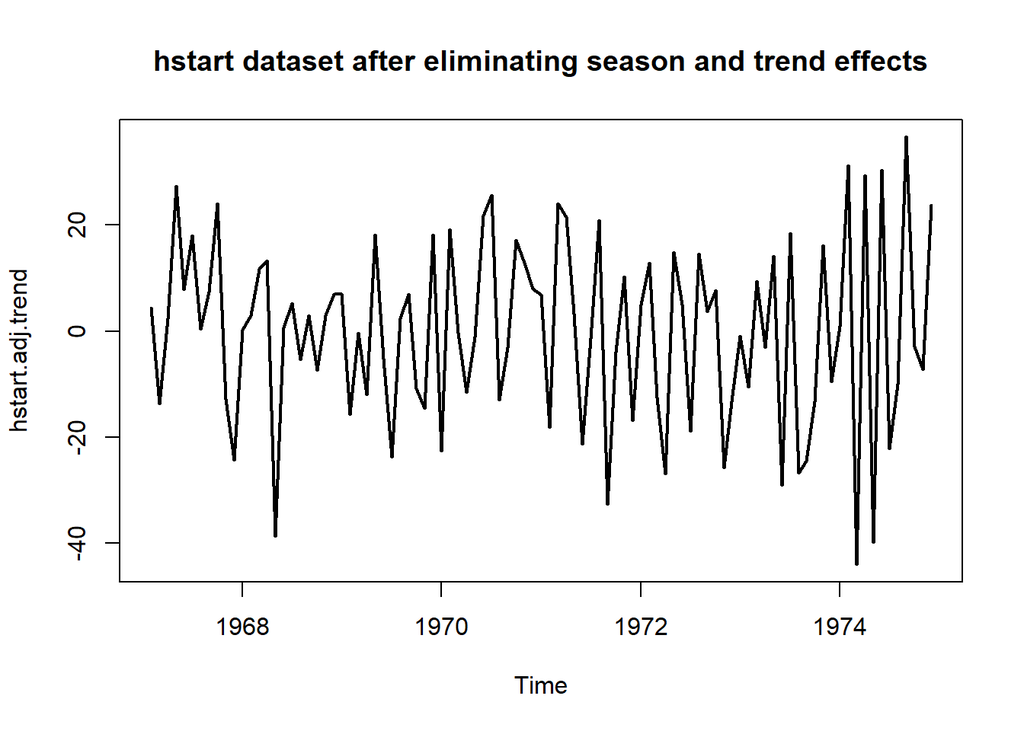

```r
hstart.adj.trend <- diff(hstart.adj.season, lag = 1)
plot(hstart.adj.trend, lwd = 2, main = 'hstart dataset after eliminating season and trend effects')
```

### 7.1.9 Backshift differencing

Remove the linear trend by applying backward differencing on timeseries created from the following models:

1. Xt ∼ 0.5t + 1 + Ut, where Ut ∼ U(−1, 1)

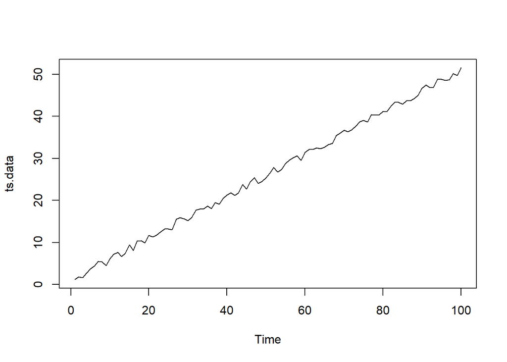

```r
t <- seq(1,100,length =100)
Ut <- runif(100,-1,1)
data <- 0.5 * t + 1 + Ut
ts.data <- ts(data)

plot(ts.data)
```

```r
yt <- diff(ts.data)

#comparison of data length
length(ts.data)
```

```
## [1] 100
```

```r
length(yt)
```

```
## [1] 99
```

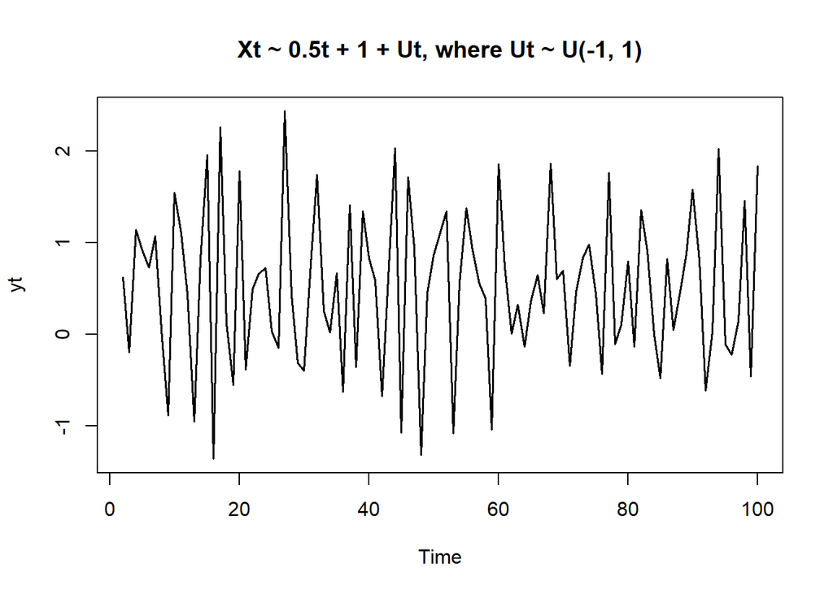

```r
plot(yt, lwd = 1.5, main = 'Xt ∼ 0.5t + 1 + Ut, where Ut ∼ U(−1, 1)')
```

2. Xt ∼ 2t^2 + 3t − 1 + Ut, where Ut ∼ U(−200, 200)

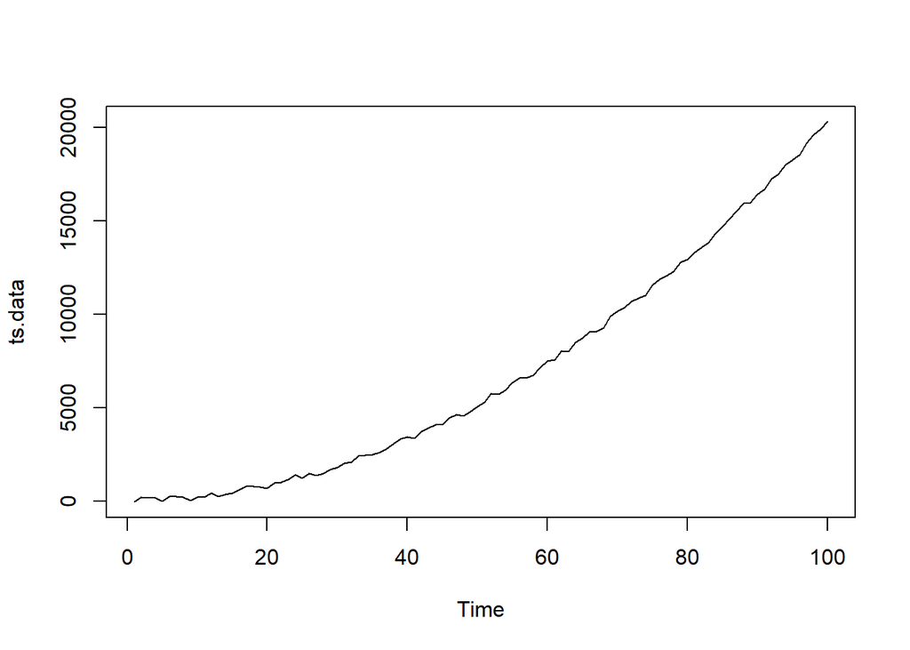

```r
t <- seq(1, 100, length=100)
Ut <- runif(100, -200, 200)
data <- 2 * t^2 + 3 * t - 1 + Ut
ts.data <- ts(data)

plot(ts.data)
```

```r
yt <- diff(ts.data, differences = 2)

#comparison of length
length(ts.data)
```

```
## [1] 100
```

```r
length(yt)
```

```
## [1] 98
```

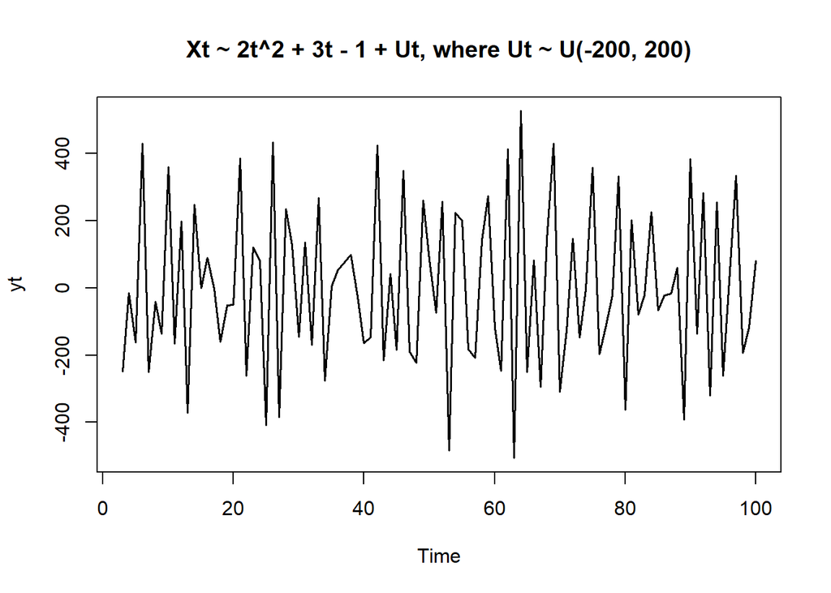

```r
plot(yt, lwd = 1.5, main = 'Xt ∼ 2t^2 + 3t − 1 + Ut, where Ut ∼ U(−200, 200)')
```

## 7.2 CO2 Data set

To test ideas and algorithms, R comes with built-in data sets. The data used in this exercise is called co2 and contains atmospheric concentrations of CO2 in parts per million.

```r
data(co2)
class(co2)
```

```
## [1] "ts"
```

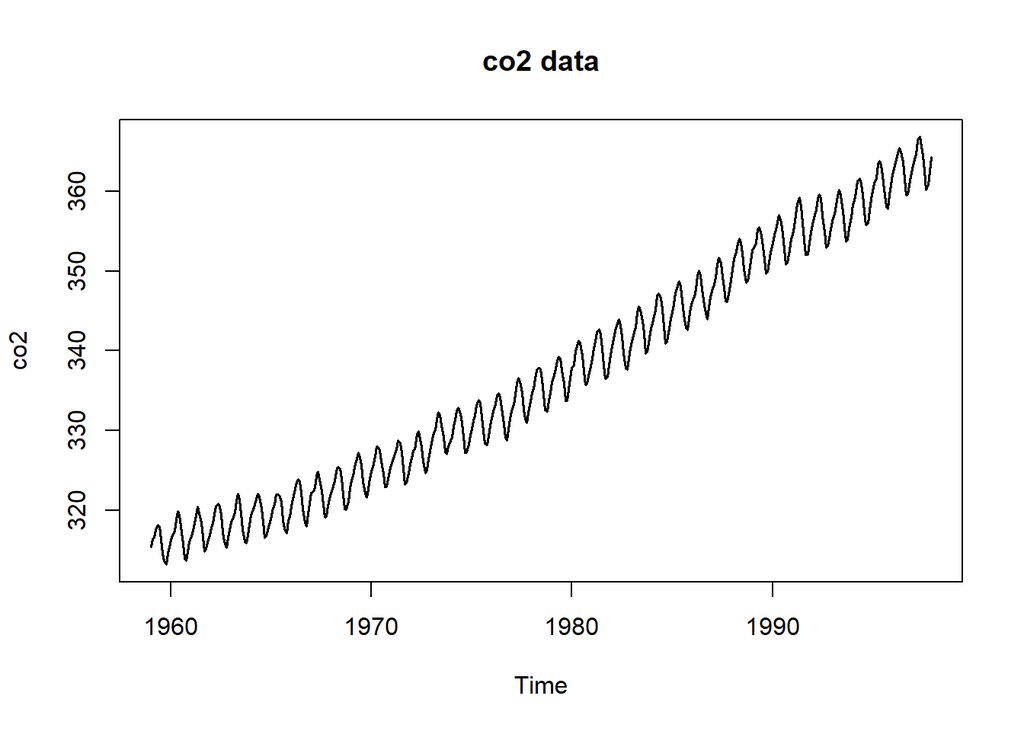

```r
plot(co2, main = 'co2 data', lwd = 1.5)
```

Use backward differencing on the co2 data to abolish the seasonality effect. Figure out what value for the lag is to choose for an optimum reduction of the seasonality? What happens if you choose other values for the lag?

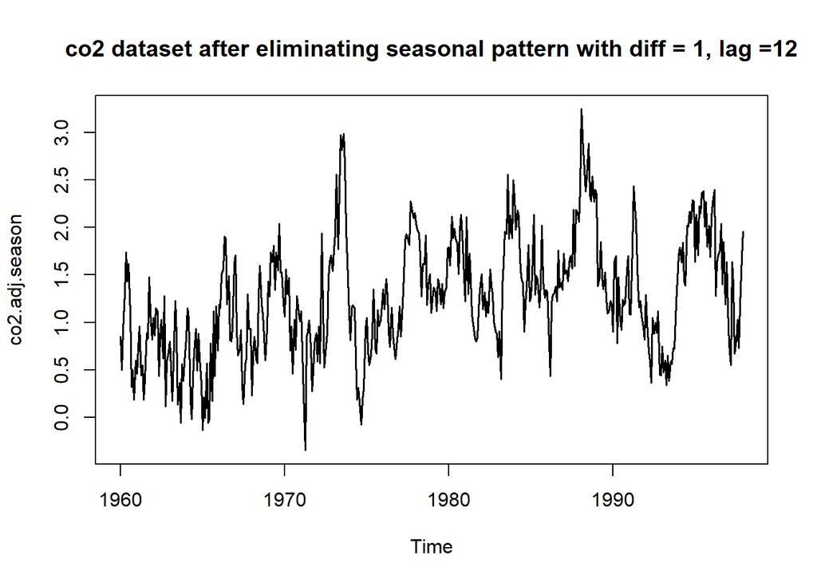

```r
co2.adj.season <- diff(co2, differences = 1, lag = 12)
plot(co2.adj.season, lwd = 1.5, main = 'co2 dataset after eliminating seasonal pattern with diff = 1, lag =12')
```

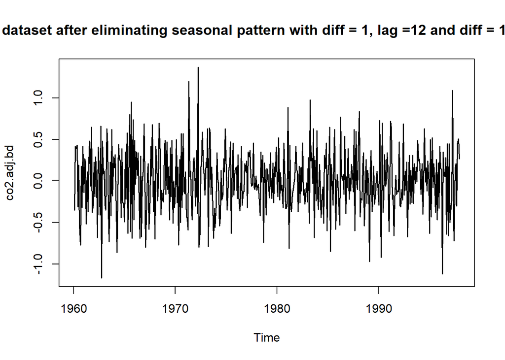

```r
co2.adj.bd <- diff(co2.adj.season, lag = 1, differences = 1)
plot(co2.adj.bd, lwd = 1.5, main = 'co2 dataset after eliminating seasonal pattern with diff = 1, lag =12 and diff = 1, lag = 1')
```

Once again have a look at the co2 data set. In this exercise you should try to decompose the series into trend, seasonality and random parts using a linear additive filter. For the seasonal part, the hints below should help you calculate the means over the same months in different years.

### 7.2.1 TREND ESTIMATION

Attention: if the freqeuncy is even, we have to split take half of the border months if we want to end up with a symmetric window.

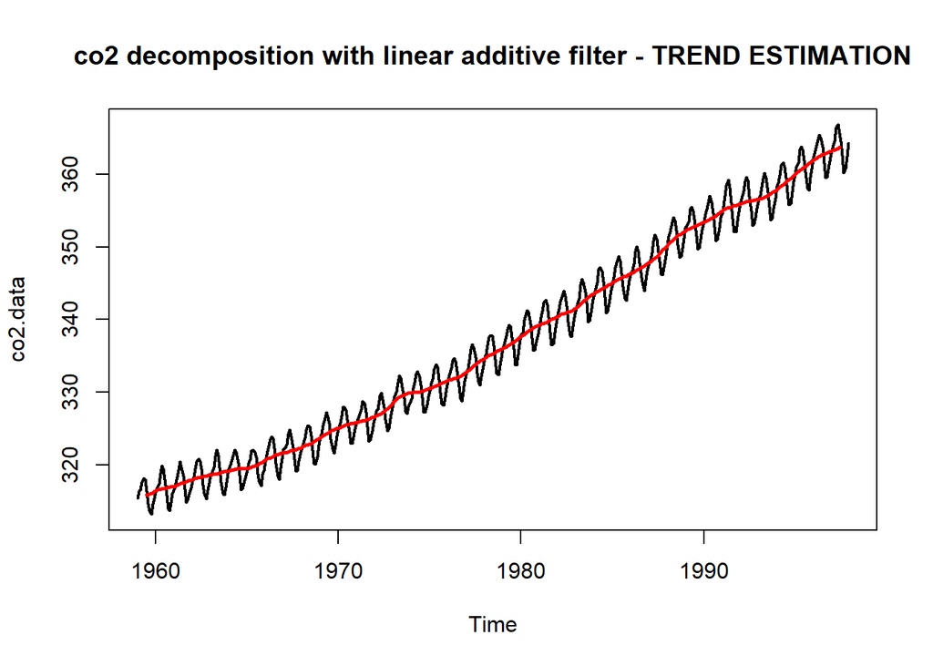

```r
co2.data <- co2
weights <- c(0.5, rep(1,11), 0.5)/12
trend <- filter(co2.data, filter = weights, sides = 2)
plot(co2.data, lwd= 2, main = 'co2 decomposition with linear additive filter - TREND ESTIMATION')
lines(trend, col= 'red', lwd = 2.5)
```

### 7.2.2 SEASONALITY ESTIMATION

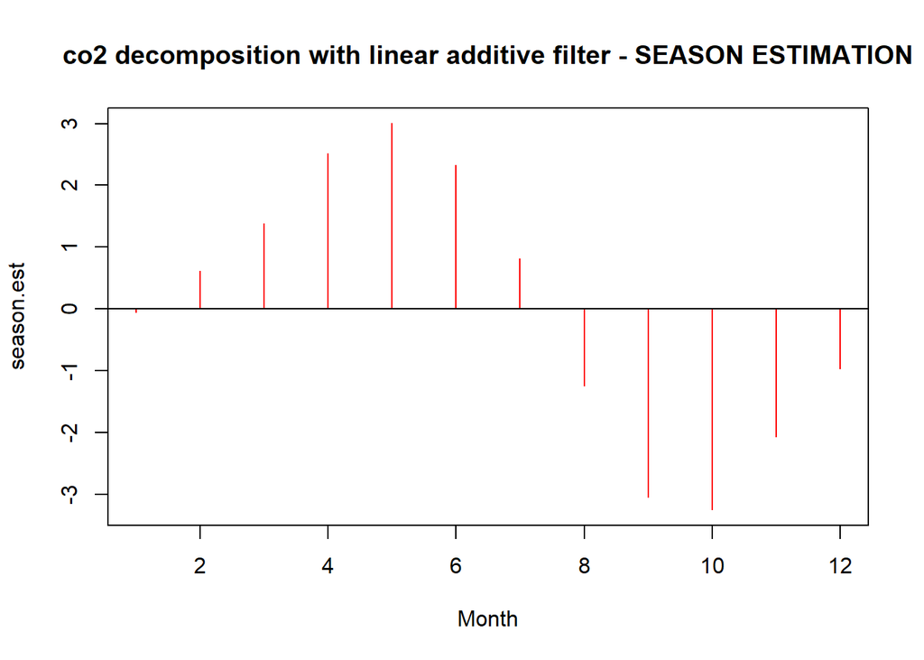

```r
weights <- c(0.5, rep(1,11), 0.5)/12
trend.est <- filter(co2, filter = weights, sides = 2)
trend.adj <- co2 - trend.est
month <- factor(rep(1:12, 39))

season.est <- tapply(trend.adj, month, mean, na.rm = T)
plot(season.est, type = 'h', xlab = 'Month', main = 'co2 decomposition with linear additive filter - SEASON ESTIMATION', col = 'red')
abline(h = 0)
```

For a combined solution have a look at the decomopose() function:

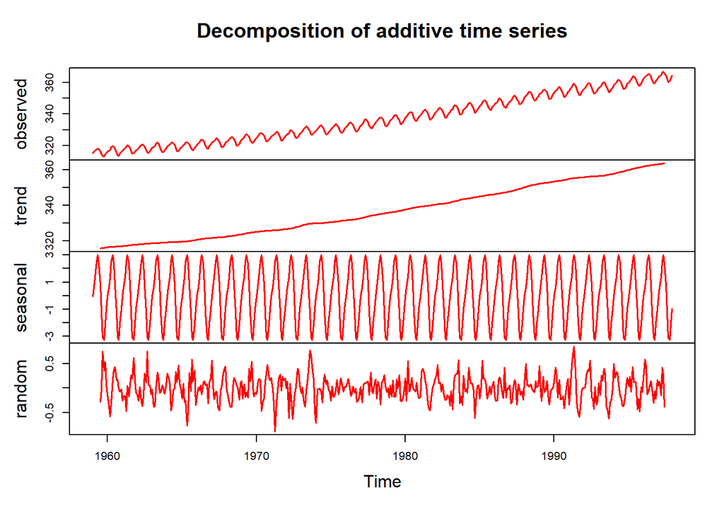

```r
co2.data <- co2
co2.data.decomp <- decompose(co2.data)
plot(co2.data.decomp, lwd = 1.5, col = 'red')
```

## 7.3 Keratin Data set

The performance of a machine that analyses the creatine content of human muscular tissue is to be investigated using 157 known samples. These samples are given to the machine one at a time for it to determine their creatine content. In this exercise, we would like to check whether it is operating correctly, i.e. the measured values does not depend on the measuring instance. We focus only on the variable “gehalt”(content) in the data.

```r
keratin <- read.table('https://stat.ethz.ch/Teaching/Datasets/WBL/kreatin.dat')
keratin.ts <- ts(keratin[,2], start = 1, frequency = 1)
```

**a) Which stochastic model should this series of data follow if the machine is working correctly?**

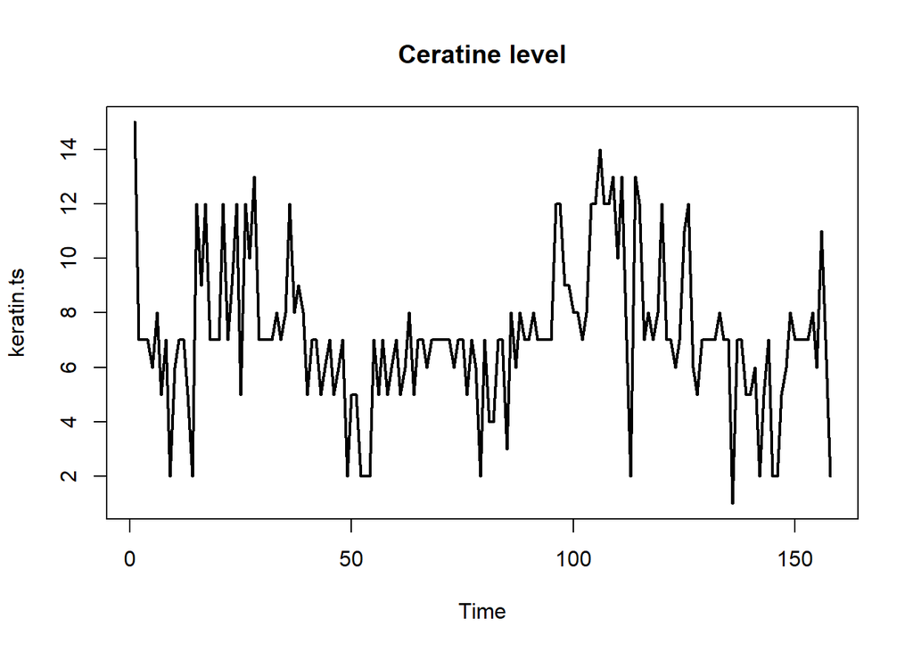

```r
plot(keratin.ts, lwd = 2, main = 'Ceratine level')
```

**Use the time series plot, the autocorrelations and the partial autocorrelations to determine whether or not these data fit the ideal model found in Part a).**

**ACF**

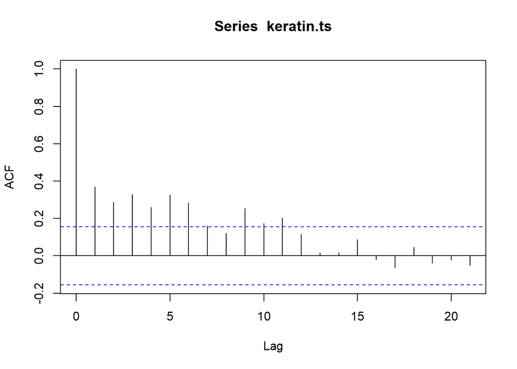

```r
keratin.acf <- acf(keratin.ts, plot = T)
```

**PACF**

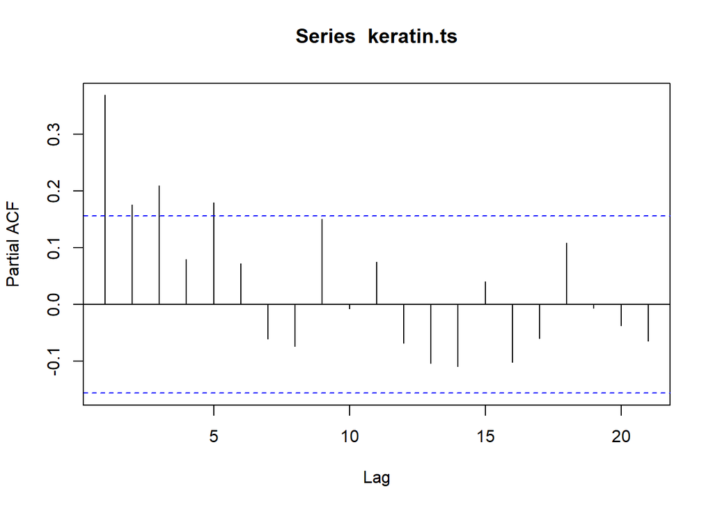

```r
keratin.pacf <- pacf(keratin.ts, plot = T)
```

## 7.4 Matching Correlograms

Below you find the plots and the correlograms of four datasets. The correlograms have been permutated. Please find for each data sets (A-D) the appropriate corellogram (1 - 4).

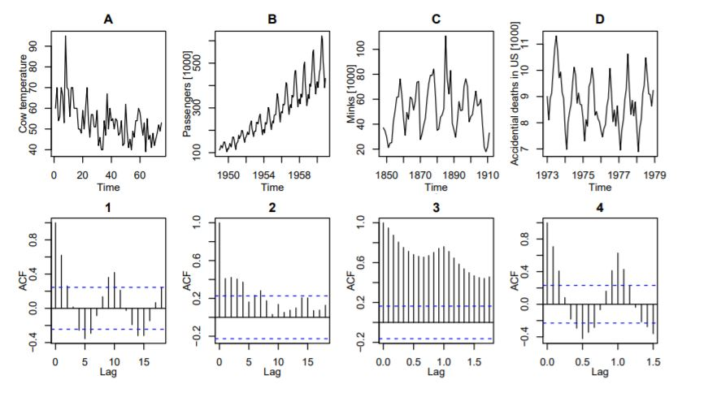

plots and correlograms

Solution: A - 2 B - 3 C - 1 D - 4

## 7.5 Chocolate, beer, electricity Data set

Let us now consider the electricity production of Australia in GWh in the period from January 1958 to December 1990. You may download the data from http://stat.ethz.ch/Teaching/Datasets/WBL/cbe.dat.

The aim of this exercise is to compare the effect of different algorithms to decompose a time series representation in trend, seasonality and remainder by means of their (partial) autocorrelation function.

```r
data <- read.table('cbe.dat', header = T)
head(data)
```

```
##   choc beer elec
## 1 1451 96.3 1497
## 2 2037 84.4 1463
## 3 2477 91.2 1648
## 4 2785 81.9 1595
## 5 2994 80.5 1777
## 6 2681 70.4 1824
```

```r
ts.elec <- ts(data[,'elec'], start = c(1958,1), end = c(1990, 12), freq= 12)
head(ts.elec)
```

```
## [1] 1497 1463 1648 1595 1777 1824
```

**a) Start by considering the plot of the time series. Why is not meaningful to interpret the correlogram of this time series? Explain in a few sentences.**

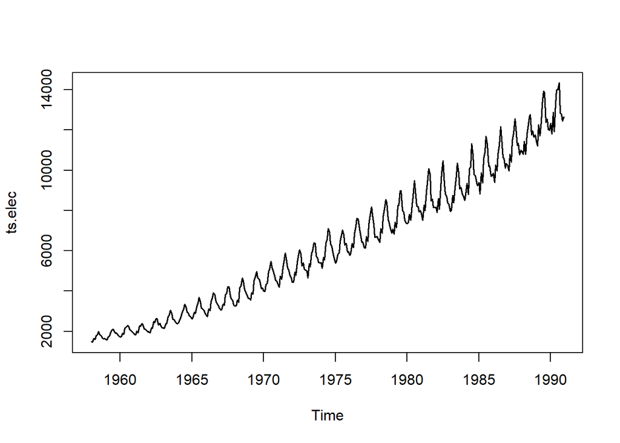

```r
plot(ts.elec, lwd = 1.5)
```

Answer: The time series displays a clear trend and a clear seasonality effect. Therefore, the fundamental assumption of the autocorrelation function analysis (stationarity) is violated.

**b) Decompose the time series into trend, seasonal component and remainder using the R function decompose(), which performs the decomposition with moving averages.**

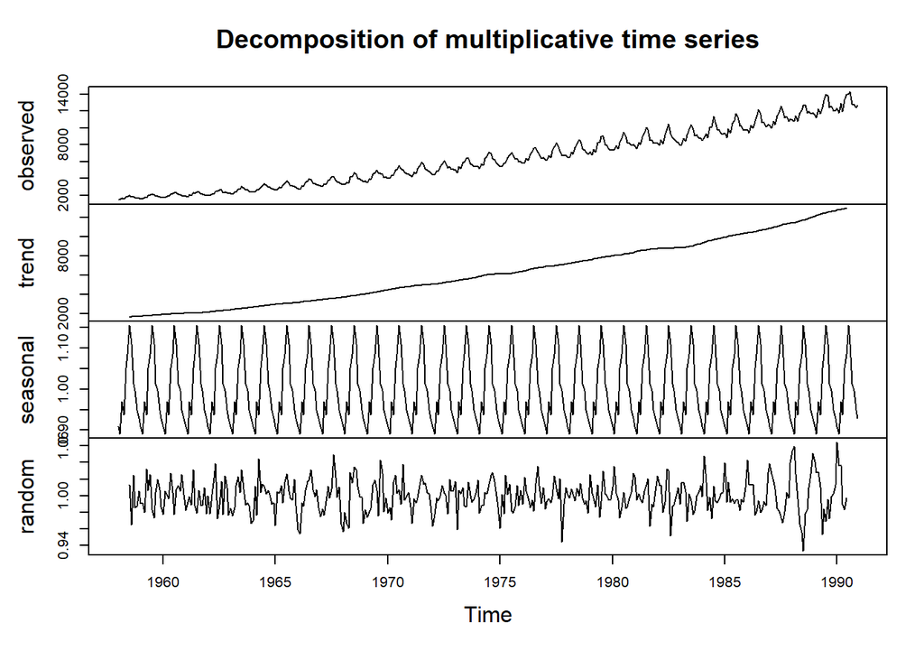

```r
elec.decomp <- decompose(ts.elec, type = 'multiplicative')
plot(elec.decomp)
```

**Plot the remainder (random) and its correlogram (acf) and interpret the plots in a few sentences.** The function employs a filter to estimate the trend; therefore, the first and the last few entries of the decomposition are not defined, i.e. the have the value NA in R. To prevent issues of R, the parameter na.action=na.pass (asking R to ignore NA entries) has to be employed.

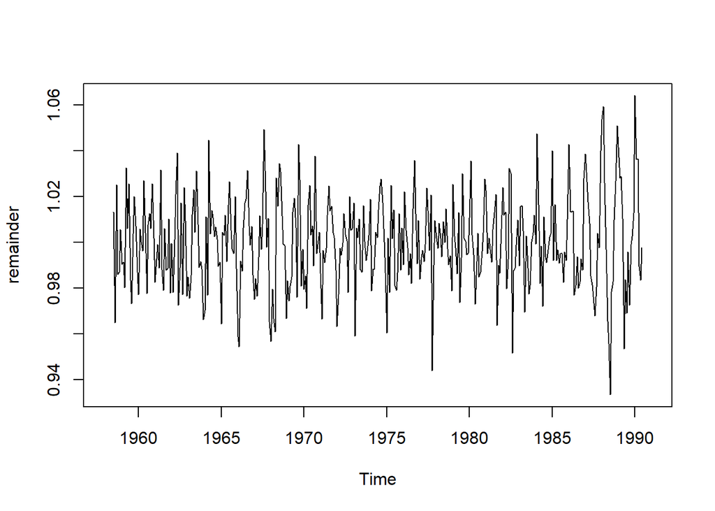

```r
plot(elec.decomp$random, ylab = 'remainder')
```

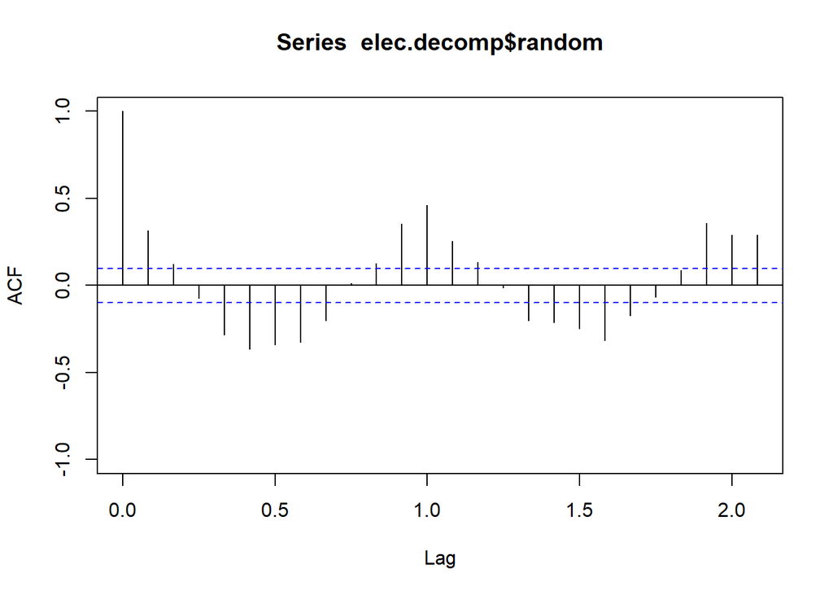

```r
acf(elec.decomp$random, na.action = na.pass, plot= T, ylim = c(-1,1))
```

Answer: The trend is removed from the time series, but we still see a periodic behaviour in the computed remainder. The period of one year equals that of the seasonal component of the original time series. These effects are also visible in the damped oscillatory behaviour of the correlogram.

**c) Decompose the log-transformed time series using the R function stl().** Estimate the seasonal effect once by averaging over all years (parameter s.window = “periodic”) and once by choosing an appropriate smoothing window (parameter s.window = …). Recall that the window length has to be odd. An appropriate smoothing window may be determined by the R-function monthplot(). For both estimation approaches (averaging and smoothing window), plot the remainder and its correlogram, and comment on the plots.

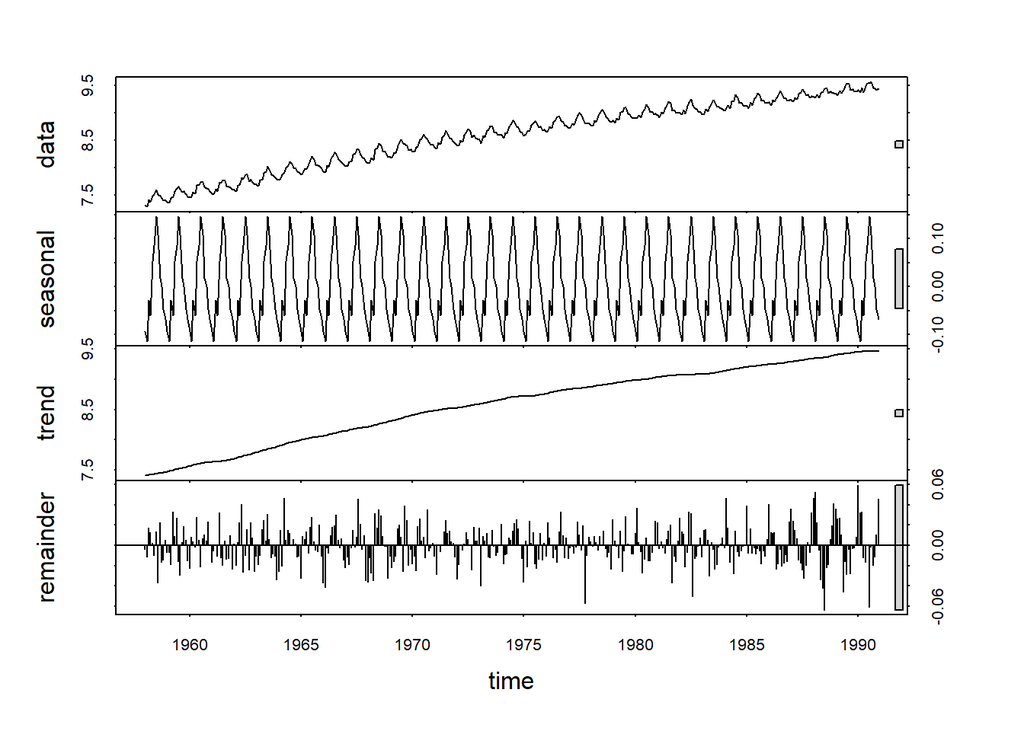

```r
elec.stl <- stl(log(ts.elec), s.window = 'per')
plot(elec.stl)
```

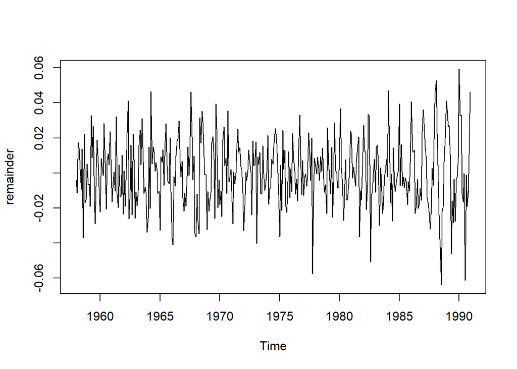

```r
plot(elec.stl$time.series[,'remainder'], ylab = 'remainder')
```

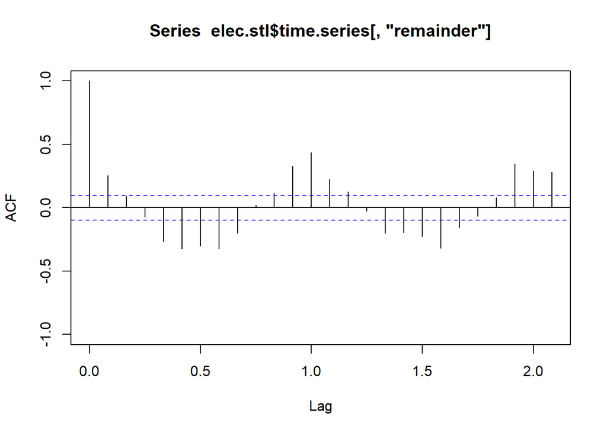

```r
acf(elec.stl$time.series[,'remainder'], plot= T, ylim =c(-1,1))
```

Answer: The result are compatible with the those of decompose(). The remainder displays still a periodic behaviour with a period of one year.

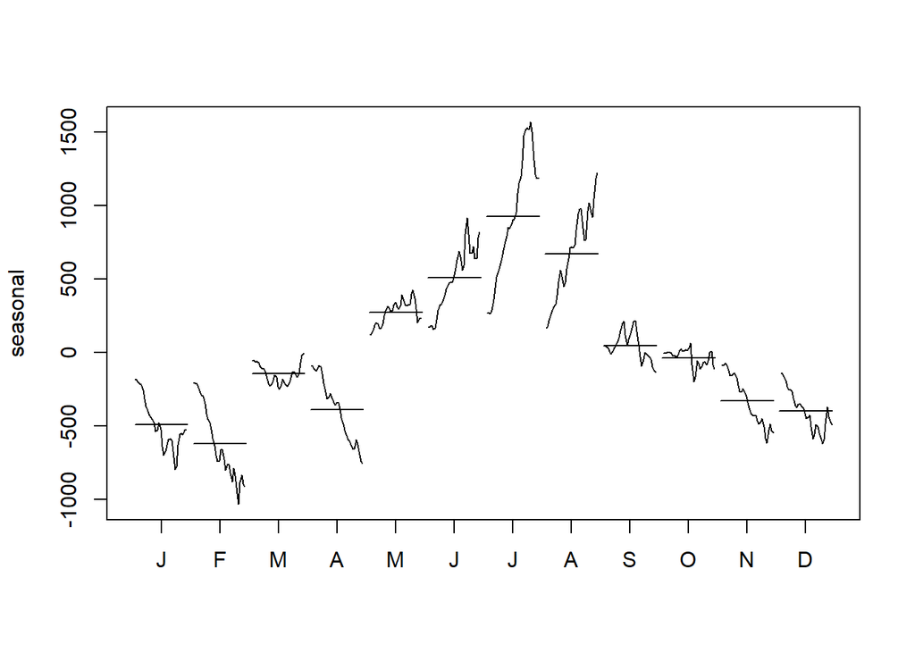

```r
a.05 <- stl(ts.elec, s.window = 5)
monthplot(a.05)
```

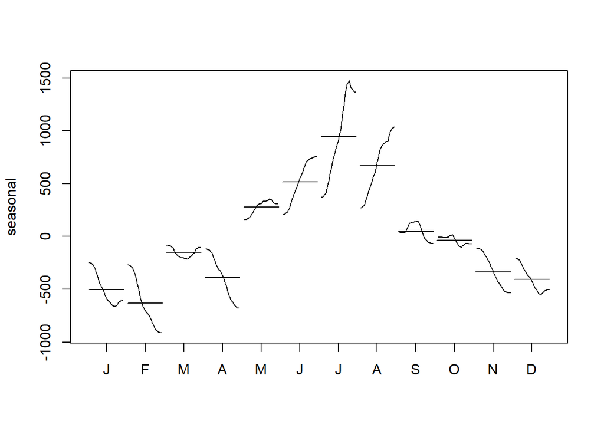

```r
a.13 <- stl(ts.elec, s.window= 13)
monthplot(a.13)
```

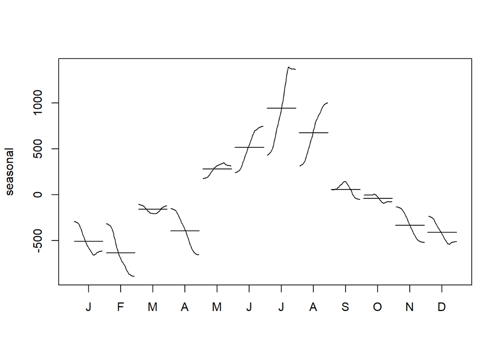

```r
a.16 <- stl(ts.elec, s.window = 16)
monthplot(a.16)
```

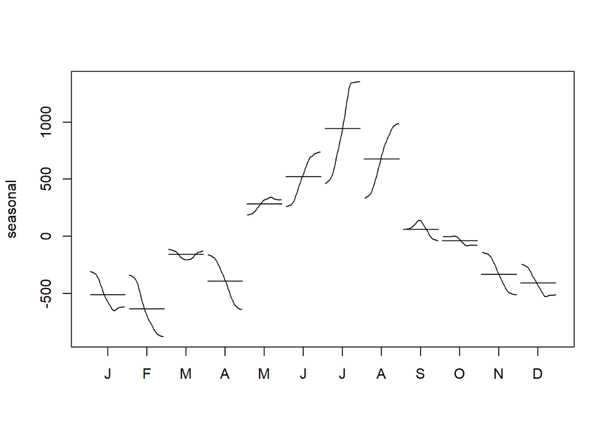

```r
a.19 <- stl(ts.elec, s.window = 19)
monthplot(a.19)
```

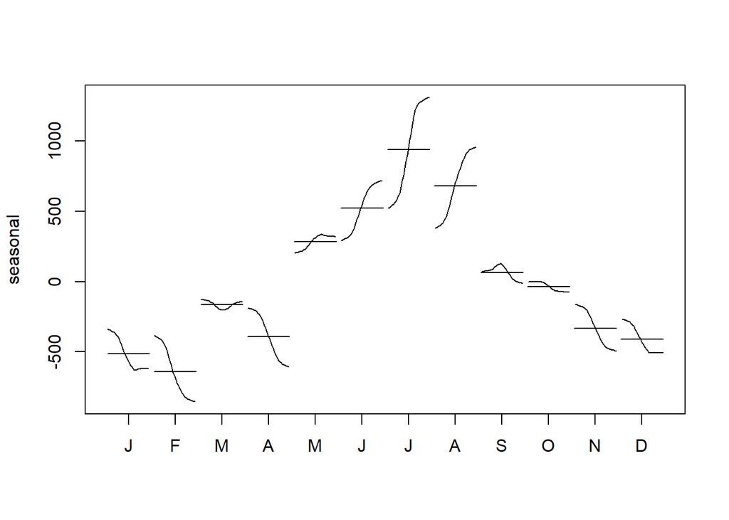

```r
a.23 <- stl(ts.elec, s.window = 23)
monthplot(a.23)
```

**Using a smoothing window of 19 (the size is chosen based on the monthplot; other values of similar magnitude yield comparable results), we find the following picture:**

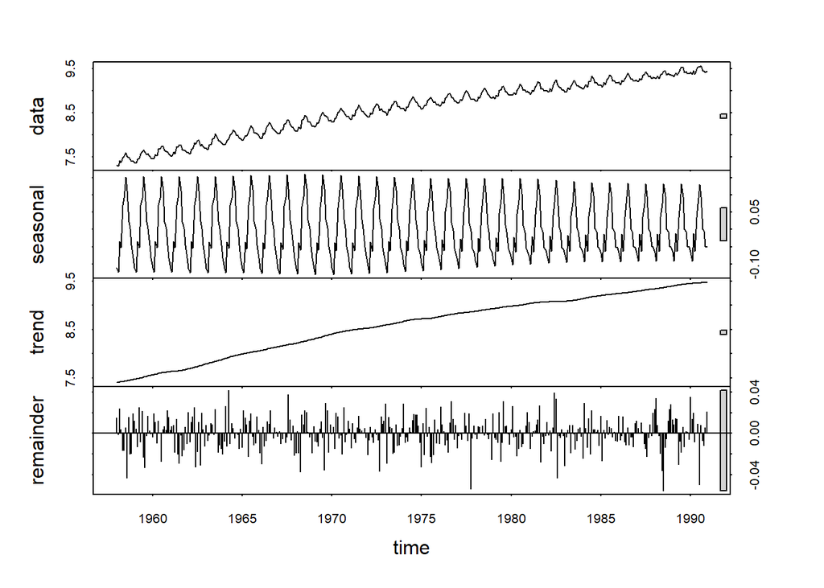

```r
elec.stl.w19 <- stl(log(ts.elec), s.window = 19)
plot(elec.stl.w19)
```

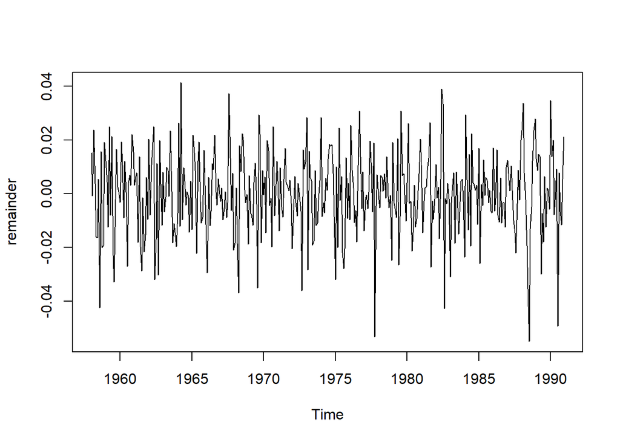

```r
plot(elec.stl.w19$time.series[,'remainder'], ylab= 'remainder')
```

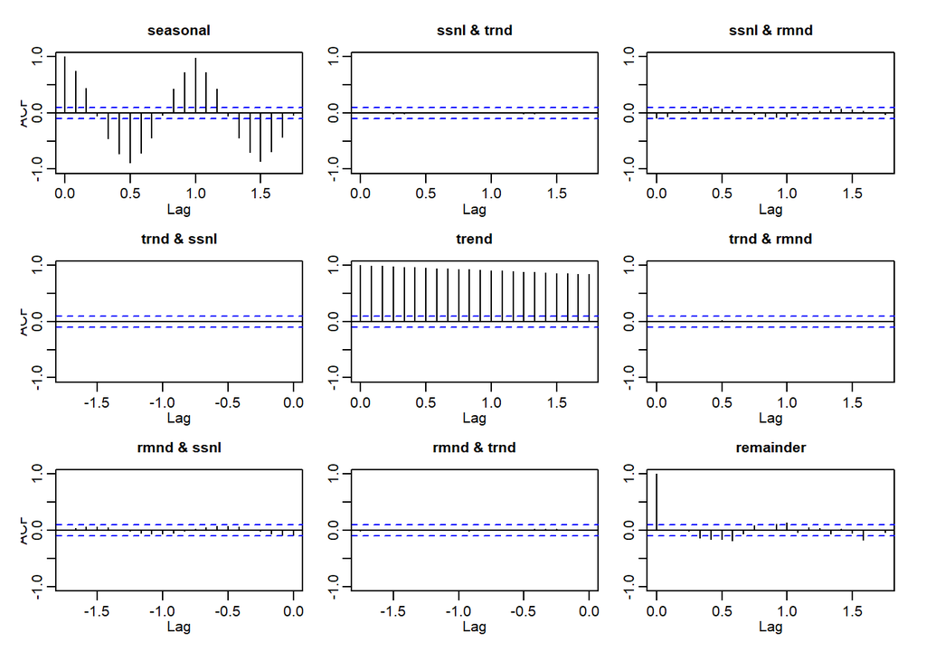

```r
acf(elec.stl.w19$time.series, plot = T, ylim = c(-1,1))
```

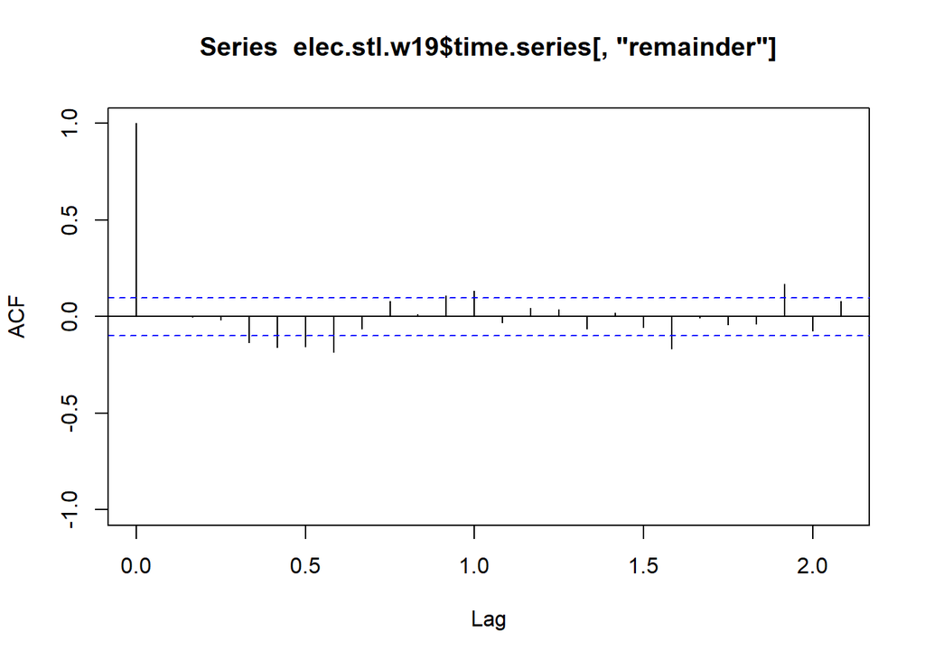

```r
acf(elec.stl.w19$time.series[,'remainder'], plot = T, ylim = c(-1,1))
```

Findings: Now, the periodicity is removed much better from the time series. The autocorrelation function of the remainder at lag 1 is not significant any more. The difference between the averaging and the smoothing window approach goes along with different concepts behind the two methods. In the averaging approach, we model the seasonal component as truly periodic and explain the slight deviations from this fitted component as a stationary random process, which in our case has the same periodicity as the underlying seasonal effect.

In the smoothing window approach, we allow the seasonal component to vary (slightly) over time, which enables to eliminate the effects with the frequency of the seasonal 4 component in the remainder. On the other hand, this approach is more prone to overfitting, since the slight deviations from a truly periodic behaviour in the seasonal component are interpreted as deterministic".

**d) Explain why you used the parameter type = “multiplicative” in Task b), and why you log-transformed the time series before performing an stl()decomposition in Task c).**

The seasonal oscillations of the time series (see plot in Task a)) are approximately proportional to the trend. Therefore, a multiplicative model is appropriate for describing the time series: Xt = mt * St * Rt A log-transformation transforms a multiplicative into an additive model: log(Xt) = log(mt) + log(St) + log(Rt)

The R function decompose() can handle multiplicative models directly, whereas stl() requires the reduction to an additive model

**e) As a last algorithm consider the differencing approach. Choose a lag of 1 and 12(months) to eliminate trend and periodic structures.**

```r
elec.diff12 <- diff(ts.elec, lag = 12)
elec.diff12.1 <- diff(elec.diff12, lag = 1)
```

Plot the resulting time series and autocorrelation function. Compare the results to the previous methods.

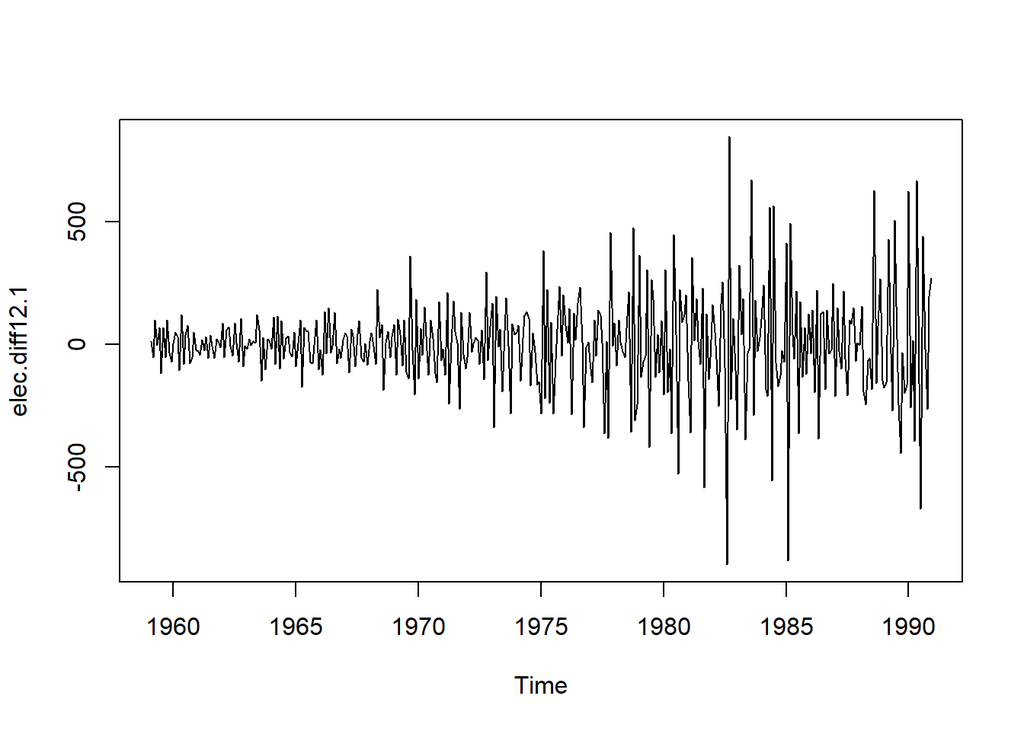

```r
plot(elec.diff12.1)
```

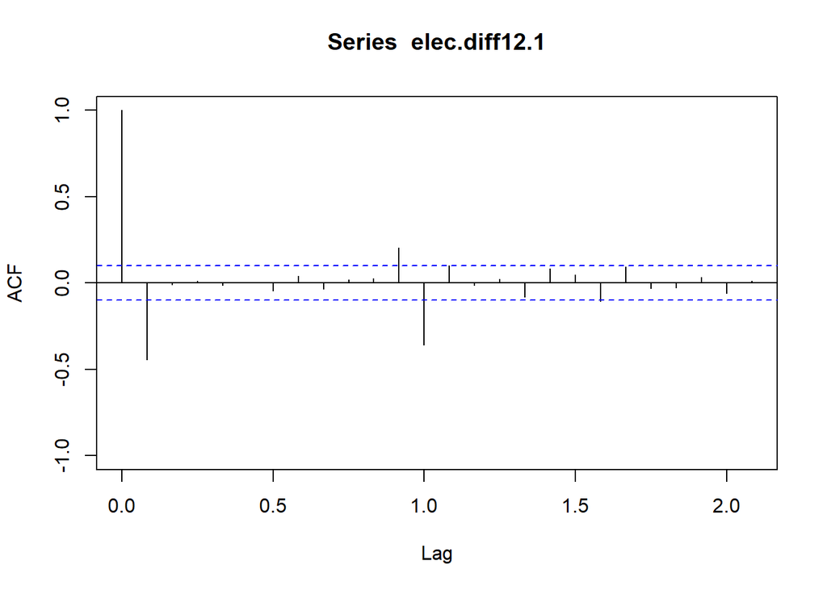

```r
acf(elec.diff12.1, ylim = c(-1,1))
```

Findings: The acf looks quite different. We have strong negative autocorrelation at lag 1 and 12. Therefore, the model is probably not linear. This method is not appropriate here.

## 7.6 Plug-in estimator

In this exercise, we will calculate the lagged scatter plot and the plug-in estimator without employing the internal R function.

1. Write a function to calculate the lagged scatter plot estimator for the autocorrelation. For this, you may extend the code given in the lecture notes.

```r
lagged <- function(data) {
n <- length(data)
lagCorrel <- rep(0, n)
for (i in 0:(n - 1)) {
lagCorrel[i + 1] = cor(data[1:(n - i)], data[(i +
1):n])
}
# return value
lagCorrel
}
```

2. Develop a function to calculate the plug-in estimator for the autocorrelation. For the implementation of the plug-in estimator we calculate the individual defining γ(k) factors first and then assign the fraction of γ(k)/γ(0) to the estimator ρˆ(k):

```r
plugIn <- function(data) {
n <- length(data)
meanData <- mean(data)
deltaX <- data - meanData
gamma0 = sum(deltaX * deltaX)/n
plugIn <- rep(0, n)
for (i in 0:(n - 1)) {
gammaK = sum(deltaX[(i + 1):n] * deltaX[1:(n -
i)])/n
plugIn[i + 1] <- gammaK/gamma0
}
plugIn
}
```

3. Calculate the two estimates for the beer and the chicken dataset. The beer and the chicken dataset is contained in the “fma”package. In case it is not already loaded, one can load it with the command library(fma).

```r
library(fma)
```

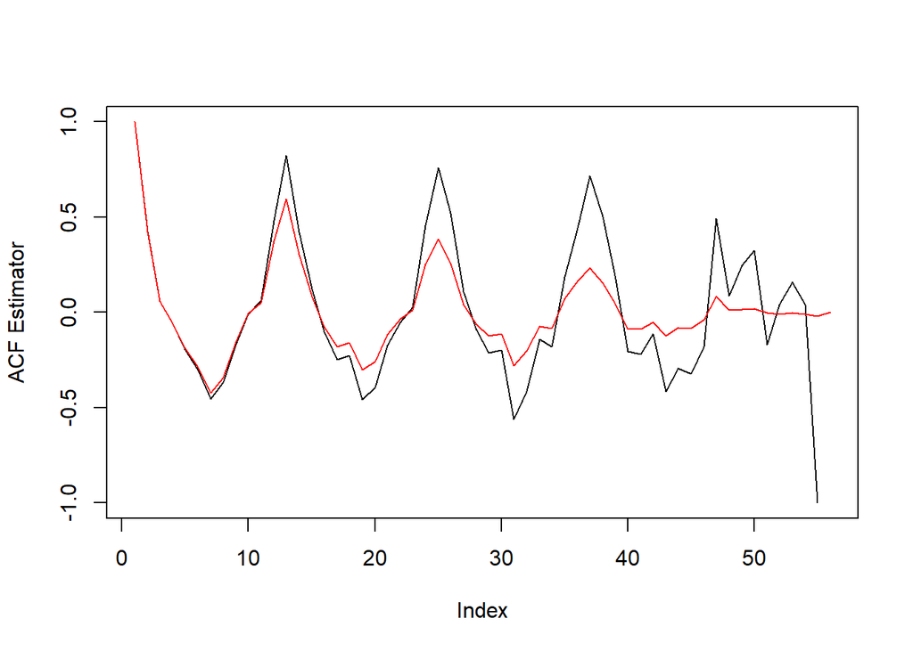

```r
lagChicken <- lagged(beer)
plugChicken <- plugIn(beer)
plot(lagChicken, type = "l", ylab = "ACF Estimator")
lines(plugChicken, col = "red")
```

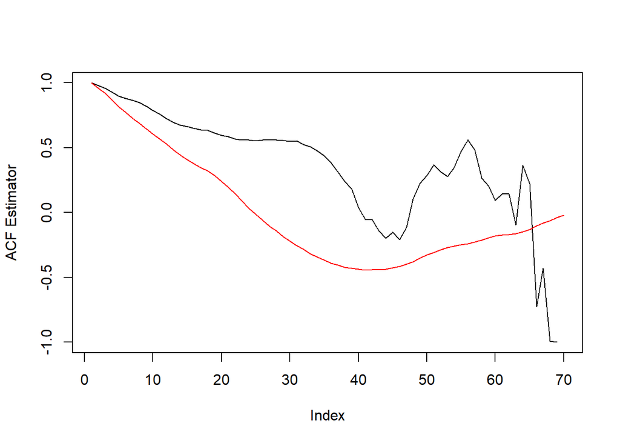

```r
lagChicken <- lagged(chicken)
plugChicken <- plugIn(chicken)
plot(lagChicken, type = "l", ylab = "ACF Estimator")
lines(plugChicken, col = "red")
```

The beer data sets displays a high agreement between the two calculation methods, whereas the chicken data sets displays a strong disagreement between the two data sets.

## 7.7 AR(1) process

In this exercise, we would like to investigate the properties of an AR(1) process.

1. Simulate a realisation of the process Xt = 0.8 · Xt−1 + et with et an innovation process of length 1000.
2. Calculate the theoretical autocorrelation function and the plug-in estimator of the autocorrelation of the simulation results in a) and plot both curves for lags from 0 to 100.
3. What is the functional dependence of the theoretical autocorrelation function on the lag k and α1 = 0.8?
4. Now compare the theoretical partical autocorrelation function with the estimated version for the simulated process. Which particularity do you observe for the two representations?

## 7.8 Data set with ts1 and ts2

In this exercise, we consider two time series ts1 and ts2, which putatively were created by an AR process. You may download the data from http://stat.ethz.ch/Teaching/Datasets/WBL/ts_S3_A2.dat

1. Visualise both time series. Are both time series stationary? What is their mean?
2. Consider the (partial) autocorrelation function and decide whether the two time series can be generated by an AR process. If yes, what is the order of the respective AR process? Hint: The partial auto correlation function of an AR(p) process displays a sudden drop for lags larger than p.

## 7.9 AR(3) model with coefficients

Let us consider the AR(3) model with coefficients α1 = 0.6, α2 = −0.5 and α3 = 0.4: Xt = 0.6 · Xt−1 − 0.5 · Xt−2 + 0.4 · Xt−3

1. Simulate one realisation of length 50 of the time series and plot it. Would you assume that this time series is stationary?
2. Calculate the estimated (partial) autocorrelation function and compare it to the theoretical function. Hint: Compare exercise 3.3 for hints.
3. Preview to week 5: Calculate the roots of the polynomial Φ(z) = 1 − α1 · z − α2 · z^2 − α3 · z^3 with the R function polyroot. What do you observe for the absolute value of the roots?